# Session 9

Batool Almarzouq

2022-08-09

## Homework

The answer as Anhal completed:

```r
## libs
library(tidyverse)
library(tidytuesdayR)
library(gapminder)
library(here)
## read the dataset

coffee_list <- tidytuesdayR::tt_load('2020-07-07')
```

```
## --- Compiling #TidyTuesday Information for 2020-07-07 ----
```

```
## --- There is 1 file available ---
```

```
## --- Starting Download ---
```

```
## --- Download complete ---
```

```r
## convert from list to datframes
coffee <- do.call(rbind,coffee_list)
coffee_list$coffee_ratings
```

```
## # A tibble: 1,339 × 43
##    total_c…¹ species owner count…² farm_…³ lot_n…⁴ mill  ico_n…⁵ company altit…⁶
##        <dbl> <chr>   <chr> <chr>   <chr>   <chr>   <chr> <chr>   <chr>   <chr>
##  1      90.6 Arabica meta… Ethiop… "metad… <NA>    meta… 2014/2… metad … 1950-2…
##  2      89.9 Arabica meta… Ethiop… "metad… <NA>    meta… 2014/2… metad … 1950-2…
##  3      89.8 Arabica grou… Guatem… "san m… <NA>    <NA>  <NA>    <NA>    1600 -…
##  4      89   Arabica yidn… Ethiop… "yidne… <NA>    wole… <NA>    yidnek… 1800-2…
##  5      88.8 Arabica meta… Ethiop… "metad… <NA>    meta… 2014/2… metad … 1950-2…
##  6      88.8 Arabica ji-a… Brazil   <NA>   <NA>    <NA>  <NA>    <NA>    <NA>
##  7      88.8 Arabica hugo… Peru     <NA>   <NA>    hvc   <NA>    richmo… <NA>
##  8      88.7 Arabica ethi… Ethiop… "aolme" <NA>    c.p.… 010/03… <NA>    1570-1…
##  9      88.4 Arabica ethi… Ethiop… "aolme" <NA>    c.p.… 010/03… <NA>    1570-1…
## 10      88.2 Arabica diam… Ethiop… "tulla… <NA>    tull… 2014/15 diamon… 1795-1…
## # … with 1,329 more rows, 33 more variables: region <chr>, producer <chr>,
## #   number_of_bags <dbl>, bag_weight <chr>, in_country_partner <chr>,
## #   harvest_year <chr>, grading_date <chr>, owner_1 <chr>, variety <chr>,
## #   processing_method <chr>, aroma <dbl>, flavor <dbl>, aftertaste <dbl>,
## #   acidity <dbl>, body <dbl>, balance <dbl>, uniformity <dbl>,
## #   clean_cup <dbl>, sweetness <dbl>, cupper_points <dbl>, moisture <dbl>,
## #   category_one_defects <dbl>, quakers <dbl>, color <chr>, …
## # ℹ Use `print(n = ...)` to see more rows, and `colnames()` to see all variable names
```

```r
coffee %>%
  count(variety)
```

```
## # A tibble: 30 × 2
##    variety                   n
##    <chr>                 <int>
##  1 Arusha                    6
##  2 Blue Mountain             2
##  3 Bourbon                 226
##  4 Catimor                  20
##  5 Catuai                   74
##  6 Caturra                 256
##  7 Ethiopian Heirlooms       1
##  8 Ethiopian Yirgacheffe     2
##  9 Gesha                    12
## 10 Hawaiian Kona            44
## # … with 20 more rows
## # ℹ Use `print(n = ...)` to see more rows
```

```r
co2 <- coffee %>%
  mutate(variety = fct_lump(variety, 10))
```

If you are new to `fct_lump()`, you can go through [this lesson](https://cran.r-project.org/web/packages/forcats/vignettes/forcats.html)

```r
## simple manipluation of the data
co <- coffee %>%
  filter(!is.na(variety), total_cup_points > 10) %>%
  mutate(variety = fct_lump(variety, 10),sort = TRUE)
```

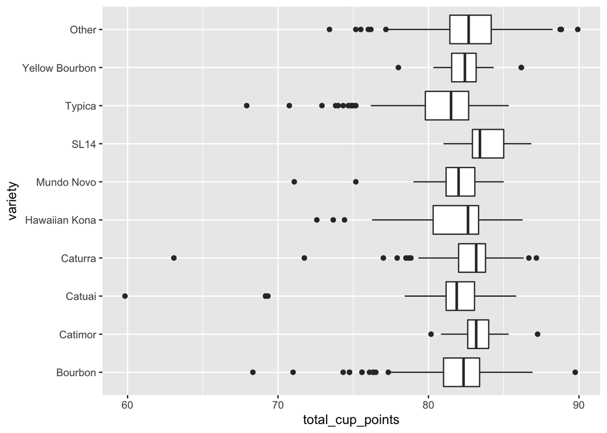

```r
## plot the data
co %>%
 ggplot( aes(total_cup_points, variety ))+
  geom_boxplot()
```

## Save plots and datasets

```r
plot <- gapminder %>%
  ggplot(aes(x = log(gdpPercap), y = lifeExp, col = year, size = pop)) +
  geom_point(alpha = 0.3) +
  geom_smooth(method = lm) +
  facet_wrap( ~ continent, scales = "free") +
  theme_bw()

gapminder_data <- gapminder
```

```r
#ggsave(here("results","plot.png"), plot, width = 15, height = 10)

#write_csv(gapminder_data, here("results","gapminder.csv"))
```

# Maniplutaing YAML in Markdown

1- toc

2- floating toc

3- [themes](https://www.datadreaming.org/post/r-markdown-theme-gallery/)

4- Changing the output

## Use yamlthis to create the header

ymlthis is an R package intended to make it easier for you to generate YAML headers

`ymlthis:::launch_yaml_addin()`

## Publish with RPub

Easy web publishing from R. Write R Markdown documents in RStudio. Share them here on RPubs.

## Exc

Install prettydoc package and change the YAML header to:

```
output:
 prettydoc::html_pretty:
   theme: cayman
   highlight: github
   math: katex
```

Publish your page in RPub?

# Using renv

Underlying the philosophy of renv is that any of your existing workflows should just work as they did before – renv helps manage library paths (and other project-specific state) to help isolate your project’s R dependencies.

The general workflow when working with renv is:

- Call `renv::init()` to initialize a new project-local environment with a private R library,

Work in the project as normal, installing and removing new R packages as they are needed in the project,

- Call `renv::snapshot()` to save the state of the project library to the lockfile (called renv.lock),

Continue working on your project, installing and updating R packages as needed.

- Call `renv::snapshot()` again to save the state of your project library if your attempts to update R packages were successful, or call renv::restore() to revert to the previous state as encoded in the lockfile if your attempts to update packages introduced some new problems.
- `renv::restore()` to restore the state of your project from renv.lock.

## Joining Datasets

```r
#create dataframes

demographics <- data.frame(
  id = c("P1", "P2", "P3"),
  age = c(40, 54, 47),
  country = c("GER", "JPN", "BRA")
  )

adverse_events <- data.frame(
  id = c("P1", "P1", "P3", "P4"),
  term = c("Headache", "Neutropenia", "Constipation", "Tachycardia"),
  onset_date = c("2020-12-03", "2021-01-03", "2020-11-29", "2021-01-27")
  )
```

```r
left_join <- left_join(demographics, adverse_events, by = "id")
```

```r
inner_join <- inner_join(demographics, adverse_events, by = "id")
```

```r
right_join(demographics, adverse_events, by = "id")
```

```
##   id age country         term onset_date
## 1 P1  40     GER     Headache 2020-12-03
## 2 P1  40     GER  Neutropenia 2021-01-03
## 3 P3  47     BRA Constipation 2020-11-29
## 4 P4  NA    <NA>  Tachycardia 2021-01-27
```

```r
full_join(demographics, adverse_events, by = "id")
```

```
##   id age country         term onset_date
## 1 P1  40     GER     Headache 2020-12-03
## 2 P1  40     GER  Neutropenia 2021-01-03
## 3 P2  54     JPN         <NA>       <NA>
## 4 P3  47     BRA Constipation 2020-11-29
## 5 P4  NA    <NA>  Tachycardia 2021-01-27
```

## Creating issues in GitHub